# Mac-D Pizza Sales Report (2015)

#### By Valentine Ezenwanne

## About the Dataset

The dataset consits of four csv files that contain informations on the orders, order_details, pizza_types and pizza. The dataset contains features such as order_id, date, quantity, pizza type, price and others.

The purpose of these datasets is to analyze and present visually the sales performance for a fictious Mac-D Pizza Place for the year 2015.

## Features Description

The fearures in the tables include:

- order_id : Unique identifier for each order placed by a table
- date: Date the order was placed (entered into the system prior to cooking & serving)
- time: Time the order was placed (entered into the system prior to cooking & serving)
- order_details_id : Unique identifier for each pizza placed within each order (pizzas of the same type and size are kept in the same row, and the quantity increases)
- pizza_id: Unique identifier for each pizza (constituted by its type and size)
- quantity: Quantity ordered for each pizza of the same type and size
- size: Size of the pizza (Small, Medium, Large, X Large, or XX Large)
- price: Price of the pizza in USD
- pizza_type_id: Unique identifier for each pizza type
- name: Name of the pizza as shown in the menu
- category: Category that the pizza fall under in the menu (Classic, Chicken, Supreme, or Veggie)
- ingredients: Comma-delimited ingredients used in the pizza as shown in the menu (they all include Mozzarella Cheese, even if not specified; and they all include Tomato Sauce, unless another sauce is specified)

## Research Questions

These are some of the questions to be answered from the analysis

- What are the top KPI's
  - How many customers did we have each day?
  - How many pizzas did we sell per day?
  - How many pizzas are typically in an order?
- Is the order impacted by trend?
- Which pizzas are the best and least sold ?
- which pizza are the top revenue generating pizza?

# Top Level KPI's

### Total pizza types

```
The total pizza types is:  32
```

### Total business days

```
The total business day is:  358
```

### Total Customers

```
The total customers is:  21350
```

### Average Daily Customers

```
The average daily customers is:  59
```

### Total Orders

```
The total orders is:  48620
```

### Average daily orders

```
The average daily order is:  135
```

### Total Quantity Sold

```
The total quantity sold is:  49574
```

### Average quantity sold per day

```
The average quantity sold perday is:  138
```

### Average pizza sold per order

```
The average pizza sold per order is:  1.0
```

### Total Revenue

```
The total revenue is:  817860.05
```

### Average Order Value

```
The average order value is:  $ 16.82
```

# Order Analysis

## Hourly Orders

|  | hour | total_orders |
| --- | --- | --- |
| 0 | 9 | 4 |
| 1 | 10 | 17 |
| 2 | 11 | 2672 |
| 3 | 12 | 6543 |
| 4 | 13 | 6203 |
| 5 | 14 | 3521 |
| 6 | 15 | 3170 |
| 7 | 16 | 4185 |
| 8 | 17 | 5143 |
| 9 | 18 | 5359 |
| 10 | 19 | 4350 |
| 11 | 20 | 3487 |
| 12 | 21 | 2528 |
| 13 | 22 | 1370 |
| 14 | 23 | 68 |

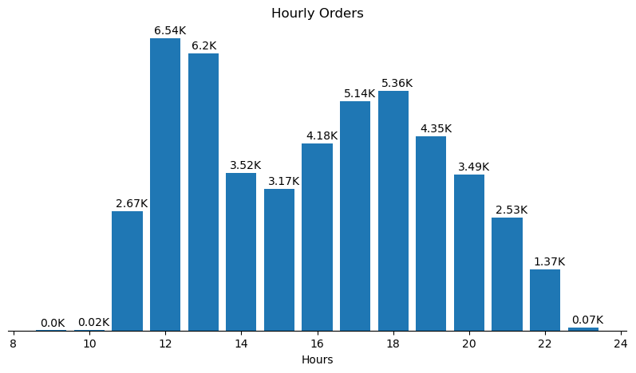

## Peak Hour Orders

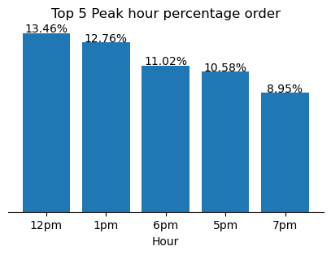

## Monthly Orders

|  | month | month_name | total_orders |
| --- | --- | --- | --- |
| 0 | 1 | January | 4156 |
| 1 | 2 | February | 3892 |
| 2 | 3 | March | 4186 |
| 3 | 4 | April | 4067 |
| 4 | 5 | May | 4239 |
| 5 | 6 | June | 4025 |
| 6 | 7 | July | 4301 |
| 7 | 8 | August | 4094 |
| 8 | 9 | September | 3819 |
| 9 | 10 | October | 3797 |
| 10 | 11 | November | 4185 |
| 11 | 12 | December | 3859 |

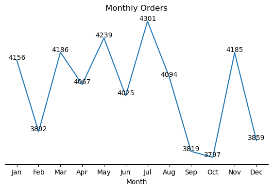

## %MoM Change in Order

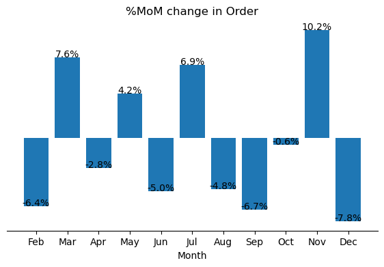

## Orders by Category

|  | category | total_orders |
| --- | --- | --- |
| 1 | Classic | 14579 |
| 2 | Supreme | 11777 |
| 3 | Veggie | 11449 |
| 0 | Chicken | 10815 |

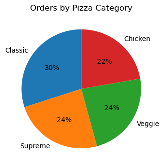

## Top 10 Selling Pizza

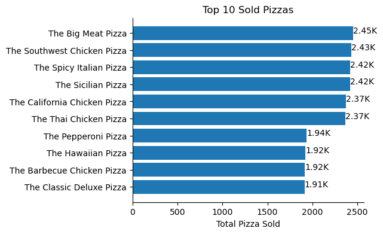

## Lowest Selling Pizza

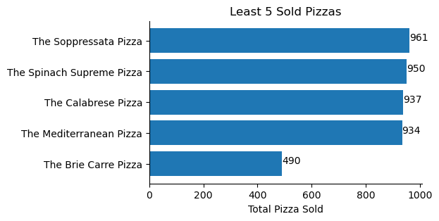

## Order by day of week

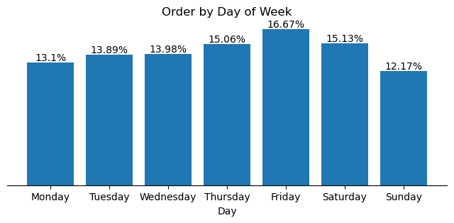

# Revenue Analysis

## Monthly Revenue

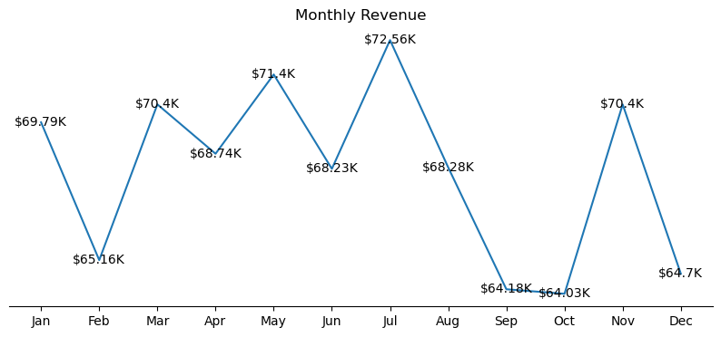

## Revenue by Pizza category

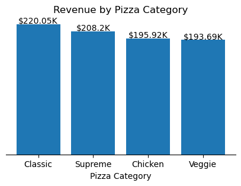

## Top five pizza by revenue

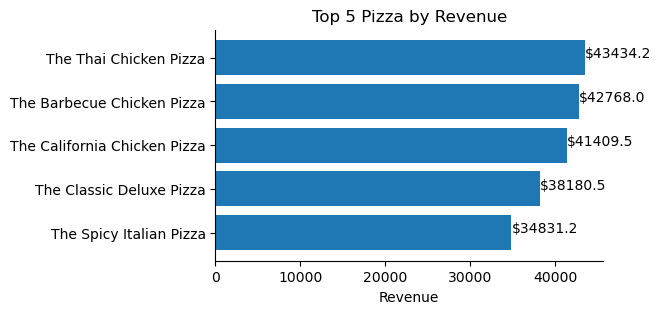

## Least five pizza by revenue

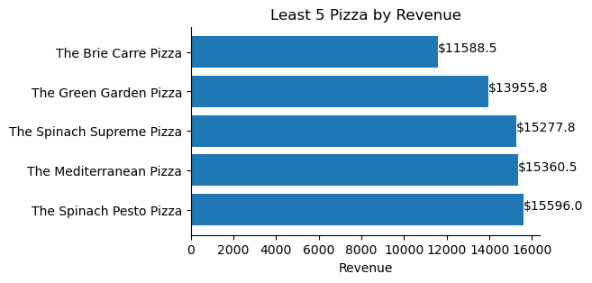

```
^C
```